# assignment

XU Ke_3035809704

2020/11/15

# question 1

```r
data = read.csv('ManagerRating.dat')
d <- ifelse(data$Origin == 'Internal', 1, -1)
cbind(data, d)
```

```
##     Manager.Rating Salary..US.000. Years.Exp   Origin  d
## 1              8.5              93         7 External -1
## 2              4.1              59        10 Internal  1
## 3              5.8              75         6 External -1
## 4              4.8              69         8 External -1
## 5              8.3              77        17 Internal  1
## 6              7.0              76         5 Internal  1
## 7              7.3              88         4 External -1
## 8              7.7              83         9 External -1
## 9              9.1             100         7 External -1
## 10             7.1              86         4 External -1
## 11             2.6              53        14 Internal  1
## 12             8.6              78         9 Internal  1
## 13             7.8              69        19 Internal  1
## 14             6.0              87        11 Internal  1
```

[output cut: 136 more lines]

```r
ols_β <- lm(Manager.Rating~d+Salary..US.000.+d*Salary..US.000.,data=data)
summary(ols_β)
```

```
##
## Call:
## lm(formula = Manager.Rating ~ d + Salary..US.000. + d * Salary..US.000.,
##     data = data)
##
## Residuals:
##     Min      1Q  Median      3Q     Max
## -3.4612 -0.7316 -0.1020  0.6318  2.9570
##
## Coefficients:
##                    Estimate Std. Error t value Pr(>|t|)
## (Intercept)       -1.815233   0.723615  -2.509   0.0132 *
## d                  0.121709   0.723615   0.168   0.8667
## Salary..US.000.    0.107242   0.009760  10.988   <2e-16 ***
## d:Salary..US.000.  0.001851   0.009760   0.190   0.8499
## ---
## Signif. codes:  0 '***' 0.001 '**' 0.01 '*' 0.05 '.' 0.1 ' ' 1
##
## Residual standard error: 1.073 on 146 degrees of freedom
## Multiple R-squared:  0.4886, Adjusted R-squared:  0.4781
## F-statistic:  46.5 on 3 and 146 DF,  p-value: < 2.2e-16
```

This is the model ‘Rating=β0+β1*Origin[Internal]+β2*Salary+β3*Origin[Internal]*Salary+ε’.

```r
d2 <- ifelse(data$Origin == 'Internal', 1, 0)
cbind(data, d2)
```

```
##     Manager.Rating Salary..US.000. Years.Exp   Origin d2
## 1              8.5              93         7 External  0
## 2              4.1              59        10 Internal  1
## 3              5.8              75         6 External  0
## 4              4.8              69         8 External  0
## 5              8.3              77        17 Internal  1
## 6              7.0              76         5 Internal  1
## 7              7.3              88         4 External  0
## 8              7.7              83         9 External  0
## 9              9.1             100         7 External  0
## 10             7.1              86         4 External  0
## 11             2.6              53        14 Internal  1
## 12             8.6              78         9 Internal  1
## 13             7.8              69        19 Internal  1
## 14             6.0              87        11 Internal  1
```

[output cut: 136 more lines]

```r
ols_α <- lm(Manager.Rating~d2+Salary..US.000.+d2*Salary..US.000.,data=data)
summary(ols_α)
```

```
##
## Call:
## lm(formula = Manager.Rating ~ d2 + Salary..US.000. + d2 * Salary..US.000.,
##     data = data)
##
## Residuals:
##     Min      1Q  Median      3Q     Max
## -3.4612 -0.7316 -0.1020  0.6318  2.9570
##
## Coefficients:
##                     Estimate Std. Error t value Pr(>|t|)
## (Intercept)        -1.936941   1.156482  -1.675   0.0961 .
## d2                  0.243417   1.447230   0.168   0.8667
## Salary..US.000.     0.105391   0.014657   7.191 3.09e-11 ***
## d2:Salary..US.000.  0.003702   0.019520   0.190   0.8499
## ---
## Signif. codes:  0 '***' 0.001 '**' 0.01 '*' 0.05 '.' 0.1 ' ' 1
##
## Residual standard error: 1.073 on 146 degrees of freedom
## Multiple R-squared:  0.4886, Adjusted R-squared:  0.4781
## F-statistic:  46.5 on 3 and 146 DF,  p-value: < 2.2e-16
```

This is the model ‘Rating=α0+α1*Origin[Internal]+α2*Salary+α3*Origin[Internal]*Salary+ε’.

# question 2

```r
library(glmnet)
library(dplyr)
data1 = read.csv('ProdTime.dat')
data2 = data1[-c(61),]
data2$rate <-data2$Run.Size/data2$Time.for.Run

manager_a <- data2 %>%
  filter(Manager == 'a')
manager_b <- data2 %>%
  filter(Manager == 'b')
manager_c <- data2 %>%
  filter(Manager == 'c')
```

```r
library(GGally)
```

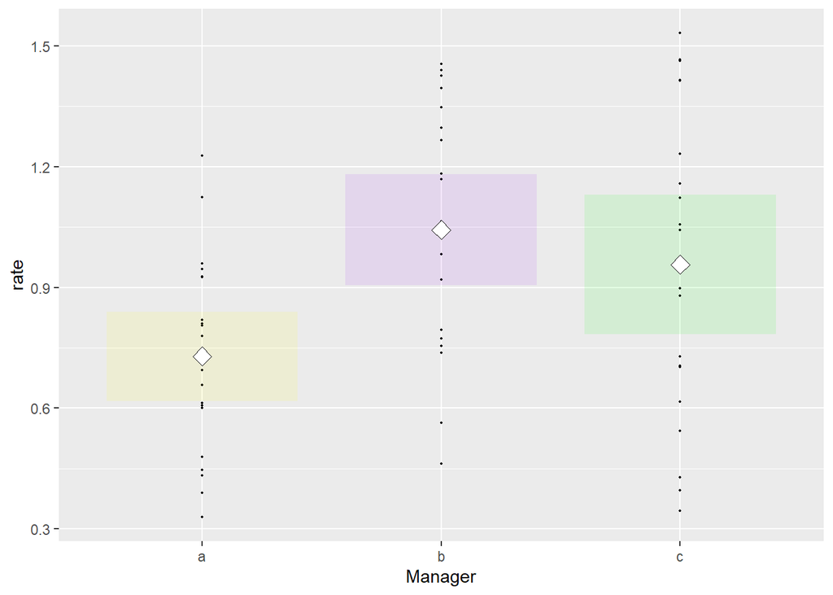

```r
mean_a <- mean(manager_a$rate)
mean_b <- mean(manager_b$rate)
mean_c <- mean(manager_c$rate)

std_a <- sd(manager_a$rate) / sqrt(length(manager_a$rate))
std_b <- sd(manager_b$rate) / sqrt(length(manager_b$rate))
std_c <- sd(manager_c$rate) / sqrt(length(manager_c$rate))

ggplot(data2, aes(x=Manager, y=rate)) +
  geom_point(size = 0.3) +
  geom_ribbon(aes(x = seq(0.6, 1.4, length.out = 60), ymin=mean_a - 2 * std_a,
                  ymax=mean_a + 2 * std_a), fill="yellow", alpha=0.1)+
  geom_ribbon(aes(x = seq(1.6, 2.4, length.out = 60), ymin=mean_b - 2 * std_b,
                    ymax=mean_b + 2 * std_b), fill="purple", alpha=0.1) +
  geom_ribbon(aes(x = seq(2.6, 3.4, length.out = 60), ymin=mean_c - 2 * std_c,
                    ymax=mean_c + 2 * std_c), fill="green", alpha=0.1) +
  stat_summary(fun="mean", geom="point", shape=23, size=4, fill="white")
```

According to the graph, b and c have overlap and a and c have overlap. Thus, we cannot compare b with c and a with c.

Because b and a have no overlap, we can say b is significantly better than a.

# question 3

```r
auto_data <- ISLR::Auto
?ISLR::Auto
```

```
## starting httpd help server ... done
```

## question3.1

```r
library(GGally)
auto_data <- ISLR::Auto
data(auto_data)
```

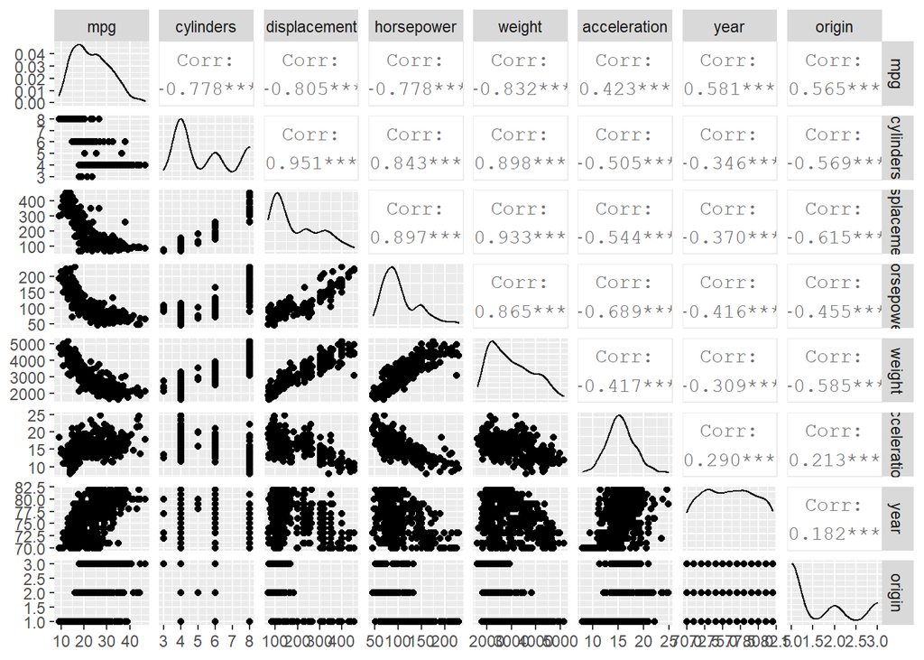

```r
ggpairs(auto_data[,1:8])
```

```r
cor(auto_data[,1:8], method='pearson')
```

```
##                     mpg  cylinders displacement horsepower     weight
## mpg           1.0000000 -0.7776175   -0.8051269 -0.7784268 -0.8322442
## cylinders    -0.7776175  1.0000000    0.9508233  0.8429834  0.8975273
## displacement -0.8051269  0.9508233    1.0000000  0.8972570  0.9329944
## horsepower   -0.7784268  0.8429834    0.8972570  1.0000000  0.8645377
## weight       -0.8322442  0.8975273    0.9329944  0.8645377  1.0000000
## acceleration  0.4233285 -0.5046834   -0.5438005 -0.6891955 -0.4168392
## year          0.5805410 -0.3456474   -0.3698552 -0.4163615 -0.3091199
## origin        0.5652088 -0.5689316   -0.6145351 -0.4551715 -0.5850054
##              acceleration       year     origin
## mpg             0.4233285  0.5805410  0.5652088
## cylinders      -0.5046834 -0.3456474 -0.5689316
## displacement   -0.5438005 -0.3698552 -0.6145351
## horsepower     -0.6891955 -0.4163615 -0.4551715
## weight         -0.4168392 -0.3091199 -0.5850054
## acceleration    1.0000000  0.2903161  0.2127458
## year            0.2903161  1.0000000  0.1815277
## origin          0.2127458  0.1815277  1.0000000
```

These results summarize the pairwise associations between the 8 variables. Weight is the most strongly varible associated with mpg.

The graphs of relationships between mpg and displacement, horsepower, weight are like log-form.

Displacement, horsepower and weight are highly correlated.

Cylinder, year, origin are factor variables.

## question3.2

### i.

```r
ols5 <- lm(mpg~year,data = auto_data)
summary(ols5)
```

```
##
## Call:
## lm(formula = mpg ~ year, data = auto_data)
##
## Residuals:
##      Min       1Q   Median       3Q      Max
## -12.0212  -5.4411  -0.4412   4.9739  18.2088
##
## Coefficients:
##              Estimate Std. Error t value Pr(>|t|)
## (Intercept) -70.01167    6.64516  -10.54   <2e-16 ***
## year          1.23004    0.08736   14.08   <2e-16 ***
## ---
## Signif. codes:  0 '***' 0.001 '**' 0.01 '*' 0.05 '.' 0.1 ' ' 1
##
## Residual standard error: 6.363 on 390 degrees of freedom
## Multiple R-squared:  0.337,  Adjusted R-squared:  0.3353
## F-statistic: 198.3 on 1 and 390 DF,  p-value: < 2.2e-16
```

year is a significant variable of mpg at the 0.05 level and the coeffient is 1.23004. If year increases 1 unit, mpg increases 1.23004 unit. If year decrease 1 unit, mpg decreases 1.23004 unit.

### ii.

```r
ols6 <- lm(mpg~year+horsepower,data = auto_data)
summary(ols6)
```

```
##
## Call:
## lm(formula = mpg ~ year + horsepower, data = auto_data)
##
## Residuals:
##      Min       1Q   Median       3Q      Max
## -12.0768  -3.0783  -0.4308   2.5884  15.3153
##
## Coefficients:
##               Estimate Std. Error t value Pr(>|t|)
## (Intercept) -12.739166   5.349027  -2.382   0.0177 *
## year          0.657268   0.066262   9.919   <2e-16 ***
## horsepower   -0.131654   0.006341 -20.761   <2e-16 ***
## ---
## Signif. codes:  0 '***' 0.001 '**' 0.01 '*' 0.05 '.' 0.1 ' ' 1
##
## Residual standard error: 4.388 on 389 degrees of freedom
## Multiple R-squared:  0.6855, Adjusted R-squared:  0.6839
## F-statistic: 423.9 on 2 and 389 DF,  p-value: < 2.2e-16
```

year is still a significant variable of mpg at the 0.05 level. When horsepower remains the same, if year increases by 1 unit, mpg increases by 0.657268 unit. When horsepower remains the same, if year decrease by 1 unit, mpg decreases by 0.657268 unit.

### iii.

```r
confint(ols5)
```

```
##                  2.5 %     97.5 %
## (Intercept) -83.076498 -56.946851
## year          1.058285   1.401786
```

```r
confint(ols6)
```

```
##                   2.5 %     97.5 %
## (Intercept) -23.2557856 -2.2225457
## year          0.5269917  0.7875439
## horsepower   -0.1441223 -0.1191866
```

95% CI’s for the coefficient of year in regression i) is [1.058285, 1.401786]

95% CI’s for the coefficient of year in regression ii) is [0.5269917, 0.7875439]

The coefficient of year in simple regression i) is an increase due to year that averages over all other differences including horsepower while the coefficient of year in ii) estimates the average mpg increase per increase in year for a fixed level of horsepower. Thus, the 95% CI’s for the two coefficients of year are different.

### iiii.

```r
ols7 <- lm(mpg~year+horsepower+year*horsepower,data = auto_data)
summary(ols7)
```

```
##
## Call:
## lm(formula = mpg ~ year + horsepower + year * horsepower, data = auto_data)
##
## Residuals:
##      Min       1Q   Median       3Q      Max
## -12.3492  -2.4509  -0.4557   2.4056  14.4437
##
## Coefficients:
##                   Estimate Std. Error t value Pr(>|t|)
## (Intercept)     -1.266e+02  1.212e+01 -10.449   <2e-16 ***
## year             2.192e+00  1.613e-01  13.585   <2e-16 ***
## horsepower       1.046e+00  1.154e-01   9.063   <2e-16 ***
## year:horsepower -1.596e-02  1.562e-03 -10.217   <2e-16 ***
## ---
## Signif. codes:  0 '***' 0.001 '**' 0.01 '*' 0.05 '.' 0.1 ' ' 1
##
## Residual standard error: 3.901 on 388 degrees of freedom
## Multiple R-squared:  0.7522, Adjusted R-squared:  0.7503
## F-statistic: 392.5 on 3 and 388 DF,  p-value: < 2.2e-16
```

The interaction is significant at the 0.05 level. When horsepower remains the same, if year increases by 1 unit, mpg increases by 2.192e+00-horsepower * 1.596e-02. When horsepower remains the same, if year decreases by 1 unit, mpg decreases by 2.192e+00-horsepower * 1.596e-02.

The increase of horsepower decreases the effect of year on mpg.

## question3.3

### i.

```r
ols8 <- lm(mpg ~ horsepower + cylinders, ISLR::Auto)
summary(ols8)
```

```
##
## Call:
## lm(formula = mpg ~ horsepower + cylinders, data = ISLR::Auto)
##
## Residuals:
##      Min       1Q   Median       3Q      Max
## -11.4378  -3.2422  -0.3721   2.3532  16.9289
##
## Coefficients:
##             Estimate Std. Error t value Pr(>|t|)
## (Intercept) 42.94842    0.77880  55.147  < 2e-16 ***
## horsepower  -0.08612    0.01119  -7.693 1.19e-13 ***
## cylinders   -1.91982    0.25261  -7.600 2.24e-13 ***
## ---
## Signif. codes:  0 '***' 0.001 '**' 0.01 '*' 0.05 '.' 0.1 ' ' 1
##
## Residual standard error: 4.584 on 389 degrees of freedom
## Multiple R-squared:  0.6569, Adjusted R-squared:  0.6551
## F-statistic: 372.4 on 2 and 389 DF,  p-value: < 2.2e-16
```

cylinders is significant at the 0.01 level. When horsepower remains the same, if cylinders increase 1 unit, mpg decreases 1.91982. When horsepower remains the same, if cylinders decreases 1 unit, mpg increases 1.91982.

### ii.

```r
ols9 <- lm(mpg ~ horsepower + as.factor(cylinders), ISLR::Auto)
summary(ols9)
```

```
##
## Call:
## lm(formula = mpg ~ horsepower + as.factor(cylinders), data = ISLR::Auto)
##
## Residuals:
##     Min      1Q  Median      3Q     Max
## -9.5917 -2.7067 -0.6102  1.9001 16.3258
##
## Coefficients:
##                       Estimate Std. Error t value Pr(>|t|)
## (Intercept)           30.77614    2.41283  12.755  < 2e-16 ***
## horsepower            -0.10303    0.01133  -9.095  < 2e-16 ***
## as.factor(cylinders)4  6.57344    2.16921   3.030  0.00261 **
## as.factor(cylinders)5  5.07367    3.26661   1.553  0.12120
## as.factor(cylinders)6 -0.34406    2.18580  -0.157  0.87501
## as.factor(cylinders)8  0.49738    2.27639   0.218  0.82716
## ---
## Signif. codes:  0 '***' 0.001 '**' 0.01 '*' 0.05 '.' 0.1 ' ' 1
##
## Residual standard error: 4.27 on 386 degrees of freedom
## Multiple R-squared:  0.7046, Adjusted R-squared:  0.7008
## F-statistic: 184.1 on 5 and 386 DF,  p-value: < 2.2e-16
```

Only when the number of cylinders is 4, it is significant at the 0.01 level in this model.

```r
anova(ols8, ols9)
```

```
## Analysis of Variance Table
##
## Model 1: mpg ~ horsepower + cylinders
## Model 2: mpg ~ horsepower + as.factor(cylinders)
##   Res.Df    RSS Df Sum of Sq      F    Pr(>F)
## 1    389 8172.5
## 2    386 7036.7  3    1135.8 20.769 1.705e-12 ***
## ---
## Signif. codes:  0 '***' 0.001 '**' 0.01 '*' 0.05 '.' 0.1 ' ' 1
```

```r
library(car)
Anova(ols9)
```

```
## Anova Table (Type II tests)
##
## Response: mpg
##                      Sum Sq  Df F value    Pr(>F)
## horsepower           1507.8   1  82.712 < 2.2e-16 ***
## as.factor(cylinders) 2349.2   4  32.217 < 2.2e-16 ***
## Residuals            7036.7 386
## ---
## Signif. codes:  0 '***' 0.001 '**' 0.01 '*' 0.05 '.' 0.1 ' ' 1
```

The difference between the average mpg when the number of cylinders is 4 and when the number of cylinders is 3 (baseline) is 6.57344, holding horsepower the same.

The result of Pr(>F) < 0.05 in anova(ols8,ols9) shows that the model which treats cylinders as a categorical/factor variable is significantly better than the model which treats cylinders as a continuous/numeric variable.

The result of Anova(ols9) shows that ‘horsepower’ and factor variable ‘cylinder’ should be included in the model.

### iii.

When ‘cylinders’ is treated as a numeric factor, it has order and numeric meaning and will be treated as linear. For example, 5 is bigger than 4.

When ‘cylinders’ is treated as a categorical factor, different cylinders means different category and does not have numeric meaning and order.

## question3.4

### i.

```r
library(leaps)
ols_fin <- regsubsets(log(mpg) ~ horsepower+weight+acceleration+horsepower*weight, data = auto_data, nvmax=100, method="exhaustive")
f1.e <- summary(ols_fin)
data.frame(variables = (1:length(f1.e$rsq)),
           r_squared = f1.e$rsq,
           rss = f1.e$rss,
           bic = f1.e$bic,
           cp = f1.e$cp)
```

```
##   variables r_squared       rss       bic        cp
## 1         1 0.7667773 10.543991 -558.7159 64.676274
## 2         2 0.7879428  9.587096 -590.0388 25.594707
## 3         3 0.7990519  9.084858 -605.1606  6.032544
## 4         4 0.8006142  9.014222 -602.2491  5.000000
```

```r
coef(ols_fin, 3)
```

```
##       (Intercept)        horsepower            weight horsepower:weight
##      4.512130e+00     -7.114546e-03     -3.618254e-04      1.199083e-06
```

```r
ols_f <- lm(log(mpg) ~ horsepower + weight + weight:horsepower, data=auto_data)
summary(ols_f)
```

```
##
## Call:
## lm(formula = log(mpg) ~ horsepower + weight + weight:horsepower,
##     data = auto_data)
##
## Residuals:
##      Min       1Q   Median       3Q      Max
## -0.44215 -0.09452 -0.00476  0.10184  0.51380
##
## Coefficients:
##                     Estimate Std. Error t value Pr(>|t|)
## (Intercept)        4.512e+00  9.123e-02  49.459  < 2e-16 ***
## horsepower        -7.115e-03  1.062e-03  -6.698 7.44e-11 ***
## weight            -3.618e-04  3.013e-05 -12.009  < 2e-16 ***
## horsepower:weight  1.199e-06  2.589e-07   4.631 4.96e-06 ***
## ---
## Signif. codes:  0 '***' 0.001 '**' 0.01 '*' 0.05 '.' 0.1 ' ' 1
##
## Residual standard error: 0.153 on 388 degrees of freedom
## Multiple R-squared:  0.7991, Adjusted R-squared:  0.7975
## F-statistic: 514.3 on 3 and 388 DF,  p-value: < 2.2e-16
```

```r
ols_fin1 <- lm(log(mpg) ~ horsepower + weight + weight:horsepower + as.factor(year) + as.factor(origin) + as.factor(cylinders), data=auto_data)
summary(ols_fin1)
```

```
##
## Call:
## lm(formula = log(mpg) ~ horsepower + weight + weight:horsepower +
##     as.factor(year) + as.factor(origin) + as.factor(cylinders),
##     data = auto_data)
##
## Residuals:
##      Min       1Q   Median       3Q      Max
## -0.33291 -0.05532  0.00484  0.06329  0.39693
##
## Coefficients:
##                         Estimate Std. Error t value Pr(>|t|)
## (Intercept)            3.848e+00  1.038e-01  37.081  < 2e-16 ***
## horsepower            -4.593e-03  7.839e-04  -5.860 1.03e-08 ***
## weight                -3.115e-04  2.821e-05 -11.043  < 2e-16 ***
## as.factor(year)71      3.291e-02  2.909e-02   1.132 0.258554
## as.factor(year)72     -1.570e-02  2.869e-02  -0.547 0.584638
## as.factor(year)73     -3.737e-02  2.588e-02  -1.444 0.149523
## as.factor(year)74      5.236e-02  3.027e-02   1.730 0.084516 .
## as.factor(year)75      5.526e-02  2.980e-02   1.855 0.064444 .
## as.factor(year)76      7.620e-02  2.845e-02   2.679 0.007716 **
## as.factor(year)77      1.417e-01  2.912e-02   4.866 1.69e-06 ***
## as.factor(year)78      1.406e-01  2.765e-02   5.085 5.86e-07 ***
## as.factor(year)79      2.332e-01  2.941e-02   7.928 2.65e-14 ***
## as.factor(year)80      3.293e-01  3.125e-02  10.538  < 2e-16 ***
## as.factor(year)81      2.590e-01  3.054e-02   8.480 5.44e-16 ***
## as.factor(year)82      3.029e-01  3.027e-02  10.008  < 2e-16 ***
## as.factor(origin)2     4.205e-02  1.751e-02   2.402 0.016818 *
## as.factor(origin)3     4.983e-02  1.722e-02   2.895 0.004022 **
## as.factor(cylinders)4  2.381e-01  5.397e-02   4.412 1.35e-05 ***
## as.factor(cylinders)5  2.699e-01  8.223e-02   3.282 0.001128 **
## as.factor(cylinders)6  1.864e-01  5.614e-02   3.321 0.000988 ***
## as.factor(cylinders)8  2.027e-01  6.007e-02   3.374 0.000820 ***
## horsepower:weight      9.094e-07  2.001e-07   4.545 7.44e-06 ***
## ---
## Signif. codes:  0 '***' 0.001 '**' 0.01 '*' 0.05 '.' 0.1 ' ' 1
##
## Residual standard error: 0.1024 on 370 degrees of freedom
## Multiple R-squared:  0.9142, Adjusted R-squared:  0.9093
## F-statistic: 187.7 on 21 and 370 DF,  p-value: < 2.2e-16
```

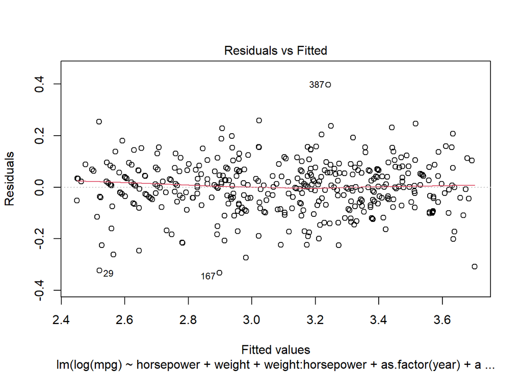

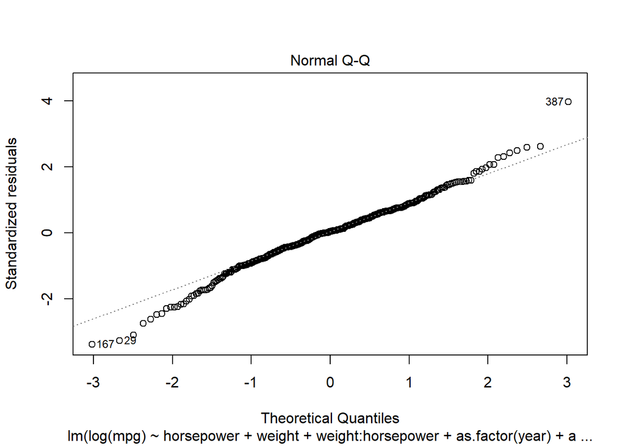

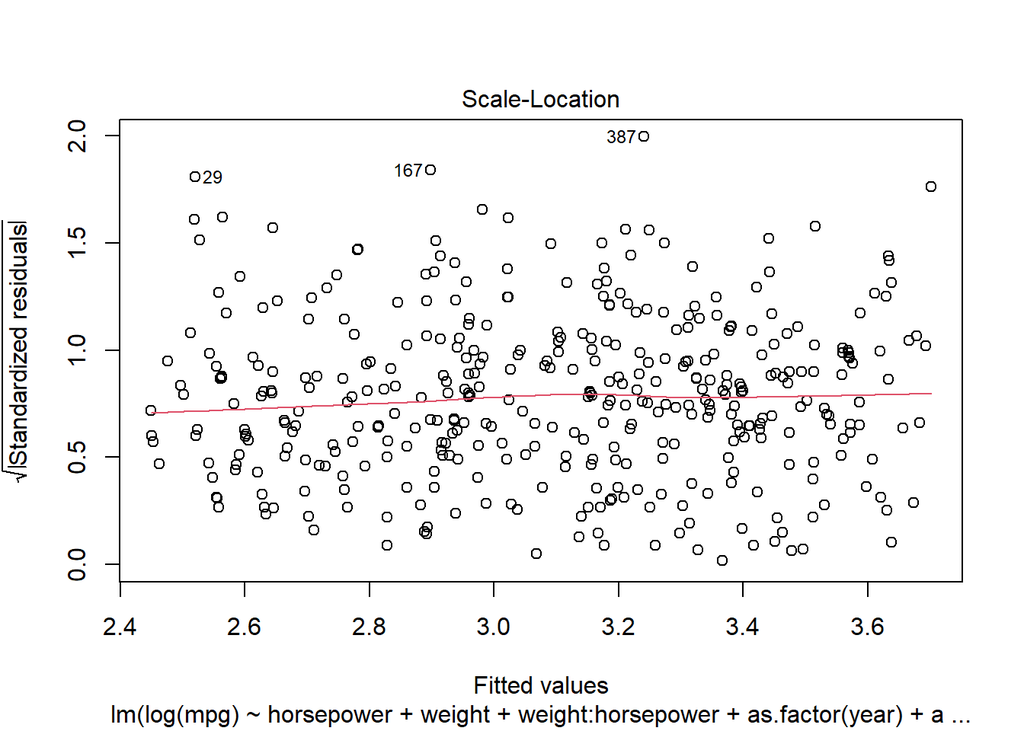

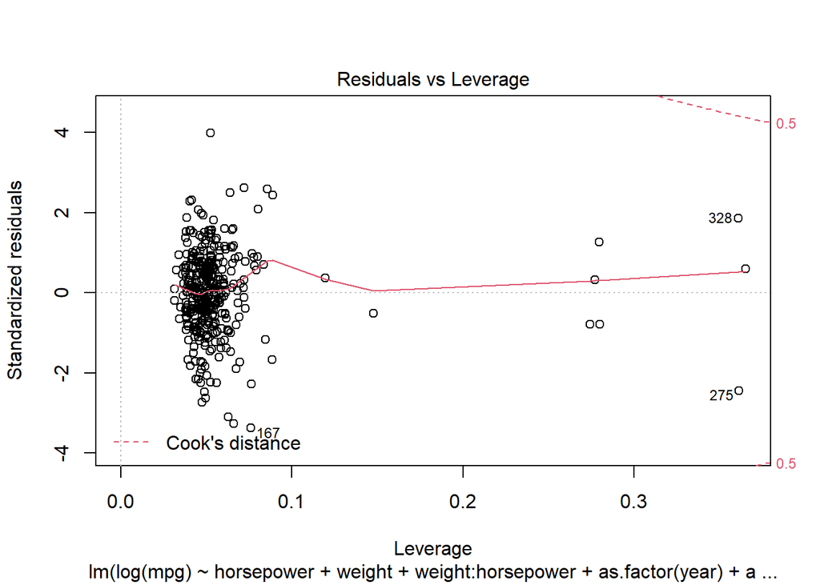

```r
plot(ols_fin1)
```

```r
anova(ols_f, ols_fin1)
```

```
## Analysis of Variance Table
##
## Model 1: log(mpg) ~ horsepower + weight + weight:horsepower
## Model 2: log(mpg) ~ horsepower + weight + weight:horsepower + as.factor(year) +
##     as.factor(origin) + as.factor(cylinders)
##   Res.Df    RSS Df Sum of Sq      F    Pr(>F)
## 1    388 9.0849
## 2    370 3.8788 18    5.2061 27.589 < 2.2e-16 ***
## ---
## Signif. codes:  0 '***' 0.001 '**' 0.01 '*' 0.05 '.' 0.1 ' ' 1
```

The final model contains numeric variable ‘horsepower’, ‘weight’, interactive term ’weight*horsepower’, factor variable ‘year’, ‘origin’ and ‘cylinders’ and the dependent variable is log(mpg).

### ii

```r
summary(ols_fin1)
```

```
##
## Call:
## lm(formula = log(mpg) ~ horsepower + weight + weight:horsepower +
##     as.factor(year) + as.factor(origin) + as.factor(cylinders),
##     data = auto_data)
##
## Residuals:
##      Min       1Q   Median       3Q      Max
## -0.33291 -0.05532  0.00484  0.06329  0.39693
##
## Coefficients:
##                         Estimate Std. Error t value Pr(>|t|)
## (Intercept)            3.848e+00  1.038e-01  37.081  < 2e-16 ***
## horsepower            -4.593e-03  7.839e-04  -5.860 1.03e-08 ***
## weight                -3.115e-04  2.821e-05 -11.043  < 2e-16 ***
## as.factor(year)71      3.291e-02  2.909e-02   1.132 0.258554
## as.factor(year)72     -1.570e-02  2.869e-02  -0.547 0.584638
## as.factor(year)73     -3.737e-02  2.588e-02  -1.444 0.149523
## as.factor(year)74      5.236e-02  3.027e-02   1.730 0.084516 .
## as.factor(year)75      5.526e-02  2.980e-02   1.855 0.064444 .
## as.factor(year)76      7.620e-02  2.845e-02   2.679 0.007716 **
## as.factor(year)77      1.417e-01  2.912e-02   4.866 1.69e-06 ***
## as.factor(year)78      1.406e-01  2.765e-02   5.085 5.86e-07 ***
## as.factor(year)79      2.332e-01  2.941e-02   7.928 2.65e-14 ***
## as.factor(year)80      3.293e-01  3.125e-02  10.538  < 2e-16 ***
## as.factor(year)81      2.590e-01  3.054e-02   8.480 5.44e-16 ***
## as.factor(year)82      3.029e-01  3.027e-02  10.008  < 2e-16 ***
## as.factor(origin)2     4.205e-02  1.751e-02   2.402 0.016818 *
## as.factor(origin)3     4.983e-02  1.722e-02   2.895 0.004022 **
## as.factor(cylinders)4  2.381e-01  5.397e-02   4.412 1.35e-05 ***
## as.factor(cylinders)5  2.699e-01  8.223e-02   3.282 0.001128 **
## as.factor(cylinders)6  1.864e-01  5.614e-02   3.321 0.000988 ***
## as.factor(cylinders)8  2.027e-01  6.007e-02   3.374 0.000820 ***
## horsepower:weight      9.094e-07  2.001e-07   4.545 7.44e-06 ***
## ---
## Signif. codes:  0 '***' 0.001 '**' 0.01 '*' 0.05 '.' 0.1 ' ' 1
##
## Residual standard error: 0.1024 on 370 degrees of freedom
## Multiple R-squared:  0.9142, Adjusted R-squared:  0.9093
## F-statistic: 187.7 on 21 and 370 DF,  p-value: < 2.2e-16
```

The effect of horsepower on mpg is -4.593e-03 + 9.094e-07*weight. If horsepower changes 1 unit and other variables remain the same, log(mpg) will changes -4.593e-03 + 9.094e-07*weight. The increase of weight will decrease the effect of horsepower on log(mpg).

The effect of weight on mpg is -3.115e-04 + 9.094e-07*horsepower. If weight changes 1 unit and other variables remain the same, log(mpg) will changes -3.115e-04 + 9.094e-07*horsepower. The increase of horpower will decrease the effect of weight on log(mpg).

Different kinds of origins makes log(mpg) different compared to baseline (origin1) at 0.05 level, holding other variables remain the same.

Different kinds of cylinders makes log(mpg) different compared to baseline (origin1) at 0.05 level, holding other variables remain the same.

Different kinds of years after 76 makes log(mpg) different compared to baseline (origin1) at 0.05 level, holding other variables remain the same.

### iii.

```r
sample <- auto_data[1,]
sample[1,] <- rep(NA, 9)
sample$origin <- 1
sample$cylinders <- 8
sample$horsepower <- 260
sample$weight <- 4000
sample$year <- 82
```

```r
mpg.s <- predict(ols_fin1, sample, interval = 'confidence')
mpg.s.true <- exp(mpg.s)
```

If treating year as a factor variable, I chose 82 as the nearest year to represent 83 and to do the prediction. The 95% CI of mpg is [15.92969, 19.09801].

```r
ols_fin_year <- lm(log(mpg) ~ horsepower + weight + weight:horsepower + year + as.factor(origin) + as.factor(cylinders), data=auto_data)
summary(ols_fin_year)
```

```
##
## Call:
## lm(formula = log(mpg) ~ horsepower + weight + weight:horsepower +
##     year + as.factor(origin) + as.factor(cylinders), data = auto_data)
##
## Residuals:
##      Min       1Q   Median       3Q      Max
## -0.36527 -0.06183 -0.00078  0.06289  0.41345
##
## Coefficients:
##                         Estimate Std. Error t value Pr(>|t|)
## (Intercept)            1.745e+00  1.660e-01  10.513  < 2e-16 ***
## horsepower            -4.587e-03  8.235e-04  -5.570 4.82e-08 ***
## weight                -3.289e-04  2.934e-05 -11.211  < 2e-16 ***
## year                   2.962e-02  1.735e-03  17.075  < 2e-16 ***
## as.factor(origin)2     3.706e-02  1.849e-02   2.004 0.045797 *
## as.factor(origin)3     5.122e-02  1.811e-02   2.828 0.004931 **
## as.factor(cylinders)4  2.448e-01  5.761e-02   4.248 2.71e-05 ***
## as.factor(cylinders)5  3.142e-01  8.761e-02   3.587 0.000378 ***
## as.factor(cylinders)6  1.873e-01  5.946e-02   3.149 0.001765 **
## as.factor(cylinders)8  2.078e-01  6.380e-02   3.256 0.001230 **
## horsepower:weight      9.533e-07  2.124e-07   4.488 9.55e-06 ***
## ---
## Signif. codes:  0 '***' 0.001 '**' 0.01 '*' 0.05 '.' 0.1 ' ' 1
##
## Residual standard error: 0.1104 on 381 degrees of freedom
## Multiple R-squared:  0.8973, Adjusted R-squared:  0.8946
## F-statistic: 332.9 on 10 and 381 DF,  p-value: < 2.2e-16
```

```r
ols_fin_year <- lm(log(mpg) ~ horsepower + weight + weight:horsepower + year + as.factor(origin) + as.factor(cylinders), data=auto_data)
sample2 <- auto_data[1,]
sample2[1,] <- rep(NA, 9)
sample2$origin <- 1
sample2$cylinders <- 8
sample2$horsepower <- 260
sample2$weight <- 4000
sample2$year <- 83
```

```r
mpg.s2 <- predict(ols_fin_year, sample2, interval = 'confidence')
mpg.s2.true <- exp(mpg.s2)
```

If treating year as a numeric variable, the 95% CI of mpg is [16.52424, 19.77841].

# question 4

```r
rm(list=ls())
```

```r
crime <- read.csv("CrimeData.csv", stringsAsFactors = F, na.strings = c("?"))
crime <- dplyr::filter(crime, state %in% c("FL", "CA"))
```

## 4.1

```r
sapply(crime, function(x) sum(is.na(x)))
```

```
##                       community                           state
##                               0                               0
##                          county                  community.code
##                             366                             367
##                            fold                      population
##                               0                               0
##                  household.size                   race.pctblack
##                               0                               0
##                   race.pctwhite                   race.pctasian
##                               0                               0
##                    race.pcthisp                   age.pct12to21
##                               0                               0
##                   age.pct12to29                   age.pct16to24
##                               0                               0
##                     age.pct65up                       num.urban
##                               0                               0
##                       pct.urban                      med.income
##                               0                               0
##                    pct.wage.inc                pct.farmself.inc
##                               0                               0
##                     pct.inv.inc                  pct.socsec.inc
##                               0                               0
##                 pct.pubasst.inc                      pct.retire
##                               0                               0
##                  med.family.inc                      percap.inc
##                               0                               0
##                    white.percap                    black.percap
##                               0                               0
##                   indian.percap                    asian.percap
##                               0                               0
##                    other.percap                     hisp.percap
##                               0                               0
##                    num.underpov                pct.pop.underpov
##                               0                               0
##                pct.less9thgrade                  pct.not.hsgrad
##                               0                               0
##                   pct.bs.ormore                  pct.unemployed
##                               0                               0
##                    pct.employed              pct.employed.manuf
##                               0                               0
```

[output cut: 93 more lines]

```
##                               0                               0
##                robberies.perpop                    num.assaults
##                               0                               1
##                 assaults.perpop                  num.burglaries
##                               1                               0
##               burglaries.perpop                   num.larcenies
##                               0                               0
##                larcenies.perpop                  num.autothefts
##                               0                               0
##               autothefts.perpop                      num.arsons
##                               0                               0
##                   arsons.perpop            violentcrimes.perpop
##                               0                               1
##         nonviolentcrimes.perpop
##                               0
```

```r
crime1 <- crime[,-c(3,4,104:120,124:127,129)]  #delete na column
crime2 <- na.omit(crime1)  #delete na row
crimenew <- crime2[,-c(3,106:121,123)]
```

```r
crimenew$state <- as.factor(crimenew$state)
crimenew$med.num.br <- as.factor(crimenew$med.num.br)
crimenew$age.pct65up <- as.numeric(crimenew$age.pct65up)
```

```r
idx.num <- which(sapply(crimenew, is.numeric))
correlation <- cor(crimenew$violentcrimes.perpop, crimenew[,idx.num], use="pairwise.complete.obs")
correlation <- abs(correlation)
correlation <- correlation[, order(correlation, decreasing=T)]
correlation
```

```
##            violentcrimes.perpop             pct.kids.nvrmarried
##                      1.00000000                      0.76776876
##                pct.kids2parents                 pct.fam2parents
##                      0.75727678                      0.71199633
##           pct.youngkids2parents                   race.pctblack
##                      0.71034437                      0.66451006
##               pct.house.nophone                pct.pop.underpov
##                      0.62915138                      0.62792831
##               pct.teens2parents                     pct.inv.inc
##                      0.60782272                      0.53954369
##                  pct.not.hsgrad                  med.family.inc
##                      0.52993496                      0.49904390
##                   race.pctwhite                      med.income
##                      0.49509341                      0.49228348
##                pct.house.vacant                  pct.hh.less3br
##                      0.48728570                      0.48448423
##                   rent.lowquart          pct.people.ownoccup.hh
##                      0.46708760                      0.46541111
##                 pct.pubasst.inc                  pct.unemployed
##                      0.46471118                      0.46294897
##                        med.rent                        rent.med
##                      0.45934217                      0.44506817
##                  rent.highquart              pct.house.ownoccup
##                      0.44325109                      0.43790685
##                pct.less9thgrade               total.pct.divorce
##                      0.43691858                      0.41892493
##              pct.occup.mgmtprof                male.pct.divorce
##                      0.41786222                      0.41004654
##              pct.house.no.plumb                 pct.occup.manuf
##                      0.40908006                      0.40736748
##              female.pct.divorce                      percap.inc
##                      0.40607158                      0.39726487
##                    other.percap                   pct.bs.ormore
##                      0.39429563                      0.39160923
##                     hisp.percap   value.ownoccup.house.lowquart
##                      0.38129773                      0.38091029
##             pct.people.dense.hh              value.ownoccup.med
##                      0.37627526                      0.37350713
##        value.ownoccup.highquart                    black.percap
##                      0.37294447                      0.36387490
```

[output cut: 47 more lines]

```
##                      0.13646907                      0.13240006
##                   indian.percap   med.owncost.aspct.hhinc.wmort
##                      0.12577323                      0.12012060
##           pct.workmom.youngkids                  pct.socsec.inc
##                      0.11629609                      0.10611634
##                  household.size               ave.people.per.hh
##                      0.08481571                      0.08478025
##              pct.born.samestate      ave.people.per.ownoccup.hh
##                      0.07042228                      0.05416054
##                       land.area                       pct.urban
##                      0.05146076                      0.02897542
##              pct.employed.manuf                     age.pct65up
##                      0.02623155                      0.02157952
##               pct.samehouse1985               pct.samestate1985
##                      0.02136295                      0.01508803
```

The set of sensible variables is pct.kids.nvrmarried, pct.kids2parents, pct.fam2parents, pct.youngkids2parents, race.pctblack, pct.house.nophone, pct.pop.underpov, pct.teens2parents, pct.inv.inc, pct.not.hsgrad, med.family.inc, race.pctwhite, med.income, pct.house.vacant, pct.hh.less3br, rent.lowquart, pct.people.ownoccup.hh, pct.pubasst.inc, pct.unemployed, med.rent.

## 4.2

### i.

```r
crimenew2 <- crimenew[,c("violentcrimes.perpop","med.num.br","state","pct.kids.nvrmarried","pct.kids2parents","pct.fam2parents", "pct.youngkids2parents", "race.pctblack", "pct.house.nophone", "pct.pop.underpov", "pct.teens2parents", "pct.inv.inc", "pct.not.hsgrad", "med.family.inc","race.pctwhite", "med.income", "pct.house.vacant", "pct.hh.less3br", "rent.lowquart", "pct.people.ownoccup.hh", "pct.pubasst.inc", "pct.unemployed", "med.rent")]
```

```r
Y.crime <- crimenew2$violentcrimes.perpop # extract Y
X.crime <- model.matrix(violentcrimes.perpop~., data=crimenew2)[, -1]
matrix.crime <- data.frame(violentcrimes.perpop = Y.crime, X.crime)
```

```r
set.seed(0) # Set seed to guarantee the result is reproducible
library(glmnet)
fit.lasso.cv <- cv.glmnet(X.crime, Y.crime, alpha=1, nfolds=10,
                        lambda = 10^seq(-3,3,length=100))
fit.lasso.cv$lambda.min
```

```
## [1] 4.328761
```

```r
coef.min <- coef(fit.lasso.cv, s="lambda.min")  #s=c("lambda.1se","lambda.min") or lambda value
coef.min <- coef.min[which(coef.min !=0),]   # get the non-zero coefficients
var.min <- rownames(as.matrix(coef.min)) # output the names
lm.input <- as.formula(paste("violentcrimes.perpop", "~", paste(var.min[-1], collapse = "+"))) # prepare for lm fomulae
lm.input
```

```
## violentcrimes.perpop ~ med.num.br2 + med.num.br4 + stateFL +
##     pct.kids.nvrmarried + pct.kids2parents + pct.youngkids2parents +
##     race.pctblack + pct.house.nophone + pct.pop.underpov + pct.inv.inc +
##     med.family.inc + pct.house.vacant + pct.hh.less3br + rent.lowquart +
##     pct.pubasst.inc + pct.unemployed + med.rent
```

```r
fit.min.lm <- lm(lm.input, data=matrix.crime)
lm.output <- coef(fit.min.lm) # output lm estimates
summary(fit.min.lm)
```

```
##
## Call:
## lm(formula = lm.input, data = matrix.crime)
##
## Residuals:
##     Min      1Q  Median      3Q     Max
## -917.72 -209.60  -26.97  170.96 1660.76
##
## Coefficients:
##                         Estimate Std. Error t value Pr(>|t|)
## (Intercept)            1.917e+03  5.712e+02   3.356 0.000878 ***
## med.num.br2           -1.178e+02  5.687e+01  -2.072 0.039040 *
## med.num.br4           -1.249e+02  1.984e+02  -0.630 0.529307
## stateFL                1.768e+02  8.068e+01   2.192 0.029068 *
## pct.kids.nvrmarried    4.020e+01  1.817e+01   2.212 0.027586 *
## pct.kids2parents      -2.172e+01  6.606e+00  -3.288 0.001111 **
## pct.youngkids2parents -5.948e+00  6.057e+00  -0.982 0.326797
## race.pctblack          1.333e+01  3.342e+00   3.989 8.10e-05 ***
## pct.house.nophone     -8.209e-02  1.303e+01  -0.006 0.994978
## pct.pop.underpov       5.172e+00  7.215e+00   0.717 0.473980
## pct.inv.inc           -1.645e+01  3.916e+00  -4.202 3.37e-05 ***
## med.family.inc         1.628e-02  4.238e-03   3.842 0.000145 ***
## pct.house.vacant       2.656e+01  1.148e+01   2.313 0.021310 *
## pct.hh.less3br         9.248e+00  2.377e+00   3.890 0.000120 ***
## rent.lowquart         -1.581e+00  5.104e-01  -3.098 0.002103 **
## pct.pubasst.inc        1.546e+01  9.486e+00   1.630 0.104048
## pct.unemployed        -3.253e+01  1.379e+01  -2.359 0.018896 *
## med.rent               1.478e+00  4.986e-01   2.964 0.003243 **
## ---
## Signif. codes:  0 '***' 0.001 '**' 0.01 '*' 0.05 '.' 0.1 ' ' 1
##
## Residual standard error: 360.7 on 350 degrees of freedom
## Multiple R-squared:  0.7195, Adjusted R-squared:  0.7059
## F-statistic: 52.82 on 17 and 350 DF,  p-value: < 2.2e-16
```

### ii.

```r
comp <- data.frame(coef.min, lm.output)
names(comp) <- c("estimates from LASSO", "lm estimates")
comp
```

```
##                       estimates from LASSO  lm estimates
## (Intercept)                   1.972207e+03 1917.02537465
## med.num.br2                  -8.433813e+01 -117.79871293
## med.num.br4                  -1.194674e+01 -124.90964359
## stateFL                       1.064927e+02  176.82016545
## pct.kids.nvrmarried           5.404602e+01   40.19817266
## pct.kids2parents             -2.177315e+01  -21.72059116
## pct.youngkids2parents        -3.831904e+00   -5.94822179
## race.pctblack                 1.339221e+01   13.32889126
## pct.house.nophone             4.914226e+00   -0.08209146
## pct.pop.underpov              7.366506e-01    5.17181806
## pct.inv.inc                  -1.047173e+01  -16.45326750
## med.family.inc                9.548793e-03    0.01628135
## pct.house.vacant              2.695896e+01   26.55521889
## pct.hh.less3br                6.322620e+00    9.24803910
## rent.lowquart                -5.490854e-01   -1.58131420
## pct.pubasst.inc               9.870803e+00   15.46084609
## pct.unemployed               -1.941300e+01  -32.53449496
## med.rent                      5.887398e-01    1.47796478
```

```r
library(leaps)
fit.exh <- regsubsets(lm.input, nvmax= length(var.min)-1, method="exhau",  matrix.crime)
f.e <- summary(fit.exh)
coef(fit.exh, which.min(f.e$bic))
```

```
##         (Intercept) pct.kids.nvrmarried    pct.kids2parents       race.pctblack
##          1999.42557            85.50989           -22.68634            13.11158
##    pct.house.vacant
##            27.75375
```

```r
var.exh <- names(coef(fit.exh, which.min(f.e$bic)))
lm.final <- as.formula(paste("violentcrimes.perpop", "~", paste(var.exh[-1], collapse = "+")))
fit.final <- lm(lm.final, data=matrix.crime)
summary(fit.final)
```

```
##
## Call:
## lm(formula = lm.final, data = matrix.crime)
##
## Residuals:
##      Min       1Q   Median       3Q      Max
## -1046.86  -224.16   -48.04   157.19  1898.65
##
## Coefficients:
##                     Estimate Std. Error t value Pr(>|t|)
## (Intercept)         1999.426    264.411   7.562 3.29e-13 ***
## pct.kids.nvrmarried   85.510     12.746   6.709 7.54e-11 ***
## pct.kids2parents     -22.686      3.346  -6.779 4.90e-11 ***
## race.pctblack         13.112      2.743   4.780 2.56e-06 ***
## pct.house.vacant      27.754     11.036   2.515   0.0123 *
## ---
## Signif. codes:  0 '***' 0.001 '**' 0.01 '*' 0.05 '.' 0.1 ' ' 1
##
## Residual standard error: 375.6 on 363 degrees of freedom
## Multiple R-squared:  0.6846, Adjusted R-squared:  0.6811
## F-statistic:   197 on 4 and 363 DF,  p-value: < 2.2e-16
```

```r
library(car)  #multicollinearity check
vif(fit.final)
```

```
## pct.kids.nvrmarried    pct.kids2parents       race.pctblack    pct.house.vacant
##            2.980325            2.737735            1.910332            1.396337
```

```r
lm.final
```

```
## violentcrimes.perpop ~ pct.kids.nvrmarried + pct.kids2parents +
##     race.pctblack + pct.house.vacant
```

### iii.

The final model is violentcrimes.perpop = 85.510*pct.kids.nvrmarried - 22.686*pct.kids2parents + 13.112*race.pctblack + 27.754*pct.house.vacant + 1999.426.

BIC is used to find the best model with relatively small number of variables.

VIF is used to check multicollinearity.